# POL478 Final Project

Jason Routsis

2022-12-13

## 1 Introduction

As our world struggles with an encroaching climate disaster, countries must make crucial decisions for their future energy generation. However, such a decision is not a simple task. As of 2021, eighty percent of the world’s energy is generated using fossil fuels. If the world is so reliant on fossil fuels, how are countries supposed to transition to an alternative form of energy? One thing is for certain, if countries desire an energy transition away from fossil fuels, they require an energy source as competitive and reliable as fossil fuels.

One source of energy that offers potential as an alternative to fossil fuels is nuclear energy. However, since its creation, nuclear energy has always been under the public eye of criticism. Nuclear energy is closely related to nuclear weapons, leading people to fear nuclear technology of any form. People the potential damage nuclear energy could exert to a state’s health if a disaster were to occur. Moreover, when disaster did strike in 1986 in Chernobyl and 2011 in Fukishima Daiichi, people’s fears were partially justified as radioactive material tainted those cities.

However, nuclear energy may have negatives closely related to it, this does not mean they out-way the positives. Nuclear energy offers extremely efficient energy generation with no resulting carbon emissions. This positive alone justifies why many countries still use nuclear energy and is why more countries today are building their own nuclear reactors. Given that climate change is an encroaching threat and an alternative energy to fossil fuels is essential, choosing nuclear might be a possible solution. Therefore, this paper offers an overview of nuclear energy today. This paper will examine different factors that contribute to how the energy landscape looks today and offer inferences about what the future of nuclear energy might entail.

### 1.1 Data

The data used in this paper is from multiple credible sources. These sources include, Emissions Database for Global Atmospheric Research (EDGAR), the Eurobarometer, International Atomic Energy Agency (IAEA), and the International Energy Agency (IEA). The information gather consists of energy, carbon emission, reactor, and survey data. All of these sources are highly renowned and some are from global nuclear organizations.

For this paper, each data source was used to show general information regarding nuclear energy today. As for whether the information has ethical issues, all of the data is open to the public and is only used to display energy data.

## 2. Analysis

In this section, multiple figures will visualize the many aspects of what contributes to the nuclear landscape today.

### 2.1 Nuclear Energy Production Around the World

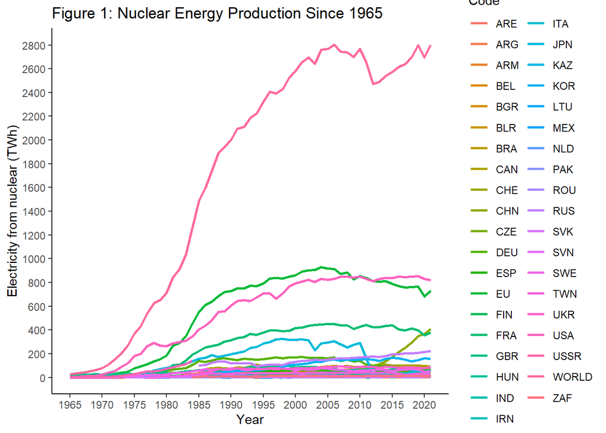

In Figure 1, nuclear energy production is shown over time, displaying trend lines for each nuclear state from 1965 to 2021. At first glance, this figure is very compact between 0 and 100 TWh of electricity, and is over shadowed by one line that reaches more than 2,800 TWh of electricity. Given the large quantity of states listed, let us first focus on the total nuclear energy production during this period and see if we can make any inferences.

#### 2.1.1 Isolate Total Nuclear Energy Production

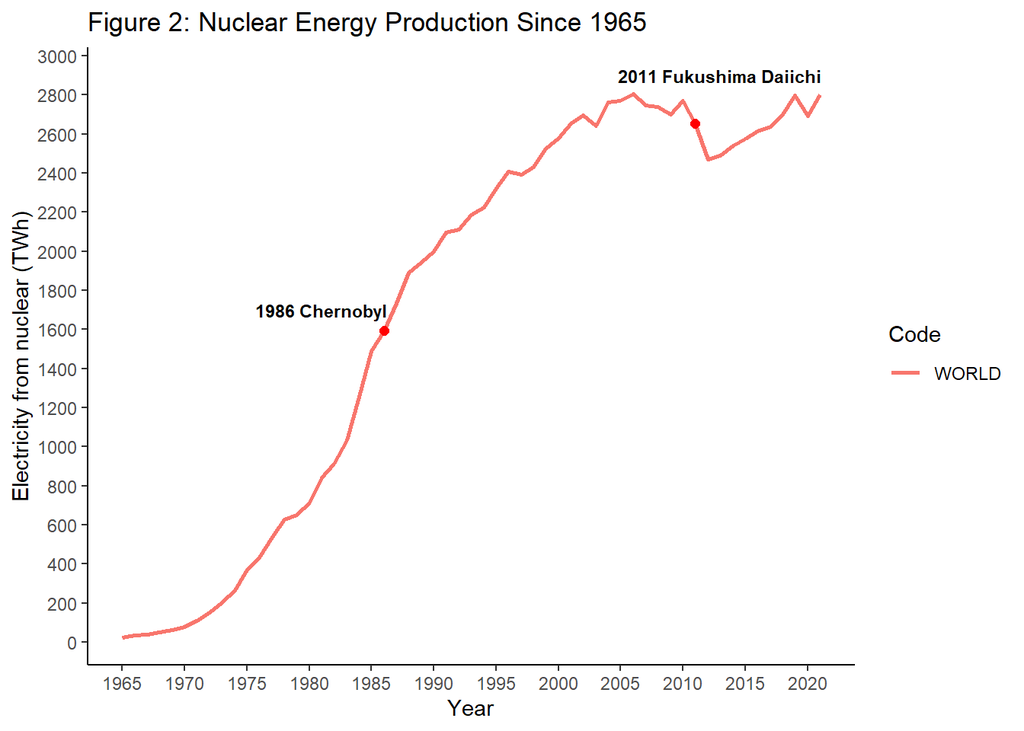

With the total nuclear energy production isolated we can now interpret it as a trend in Figure 2. In Figure 2, the trend line rapidly increases between 1965 and 2000, but then begins to plateaus in the remaining years. Additionally, two points signify the Chernobyl and Fukushima Daiichi incidents. Looking at the slope before and after Chernobyl, the total nuclear energy production does not seem to decrease, but rate at which production increased over the years did decrease. Moreover, after Fukushima Daiichi, the total nuclear energy production greatly decreased. From these points, we can infer that nuclear energy incidents may have caused countries to second guess the energy source, causing the total energy production to decrease. The total trend line does provide some broad information about nuclear energy but does not allow us to visualize how individual countries changed their nuclear energy production during this period.

#### 2.1.2 Top 12 States With the Highest Nuclear Energy Production

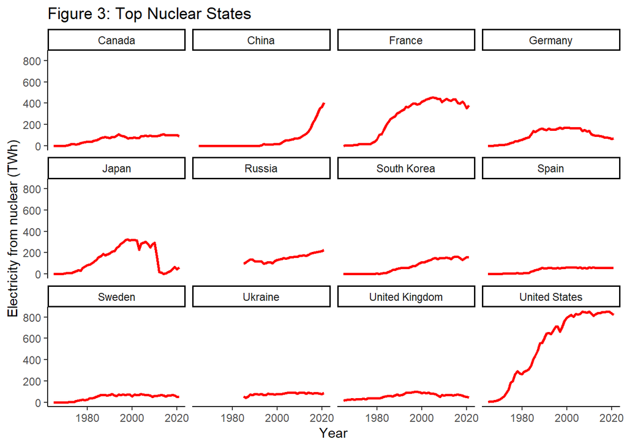

In Figure 3, we isolate the top 12 nuclear energy producing states. From this visual breakdown, four distinct groupings are shown. The first group includes states that have had a stagnant amount of energy production through most of its history (Canada, Spain, Sweden, Ukraine, and United Kingdom). The second group includes states that increased greatly in energy production but have plateaued in recent years (France and the United States). The third group includes states that experienced a high period of energy production but have only decreased ever since (Germany and Japan). The final group includes states that were late to the nuclear scene but have only increased in recent years (China, Russia, and South Korea). These four groups provide a better reference for how nuclear energy has evolved of time. For example, historically very nuclear states like France and the United States have reached a maximum with no sign of increasing production. On the other hand, new nuclear states like China and Russia are rapidly increasing their production capabilities.

### 2.2 Global Summary of Reactors (Operational, Under Construction, Shutdown, and Planned)

To further understand the current state of nuclear energy, this next section will examine reactors and reactor conditions across the globe.

#### 2.2.1 Operational Reactors

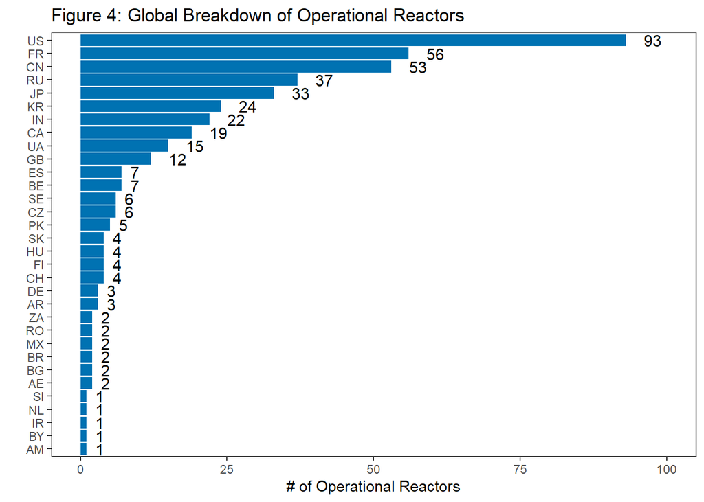

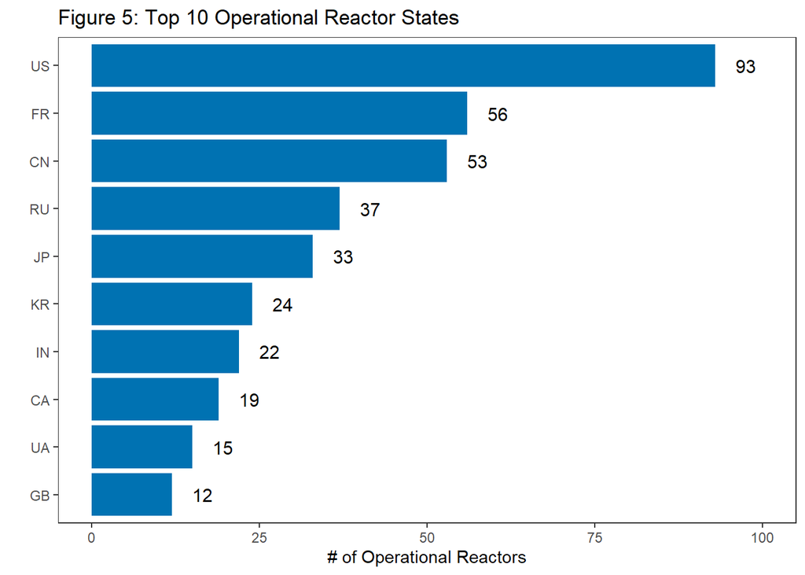

The first thing to consider when comparing reactors is the current amount that are operational. Looking at Figure 4, the graph reveals many states currently possess a small amount of reactors, some more than others. Generally speaking, the distribution of operational reactors is confined among a couple of states. To better visualize the states with the largest amount of operational reactors, Figure 5 highlights the top 10. Comparing these countries to the ones listed in Figure 3, all but India were listed as some of the top nuclear energy producing states. Additionally, as seen in Figure 3, China is a recent player when it comes to nuclear energy, yet they rank number 3 in total amount of operational reactors.

#### 2.2.2 Summary of Reactors

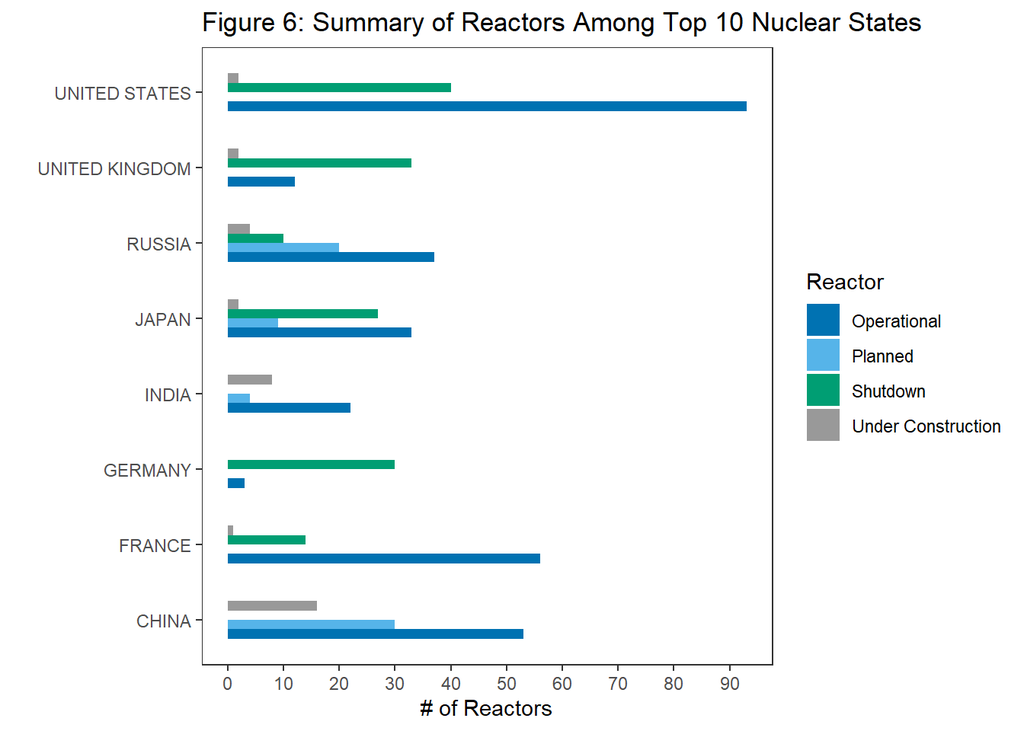

### 2.3 Nuclear Energy Comparison

One thing that was interesting about Figure 3 was specific states who were once for nuclear energy suddenly decreasing their production levels. To further understand this phenomenon, this next section will compare some of the top 12 nuclear states in order to discern why states changed production levels.

#### 2.3.1 France and Germany

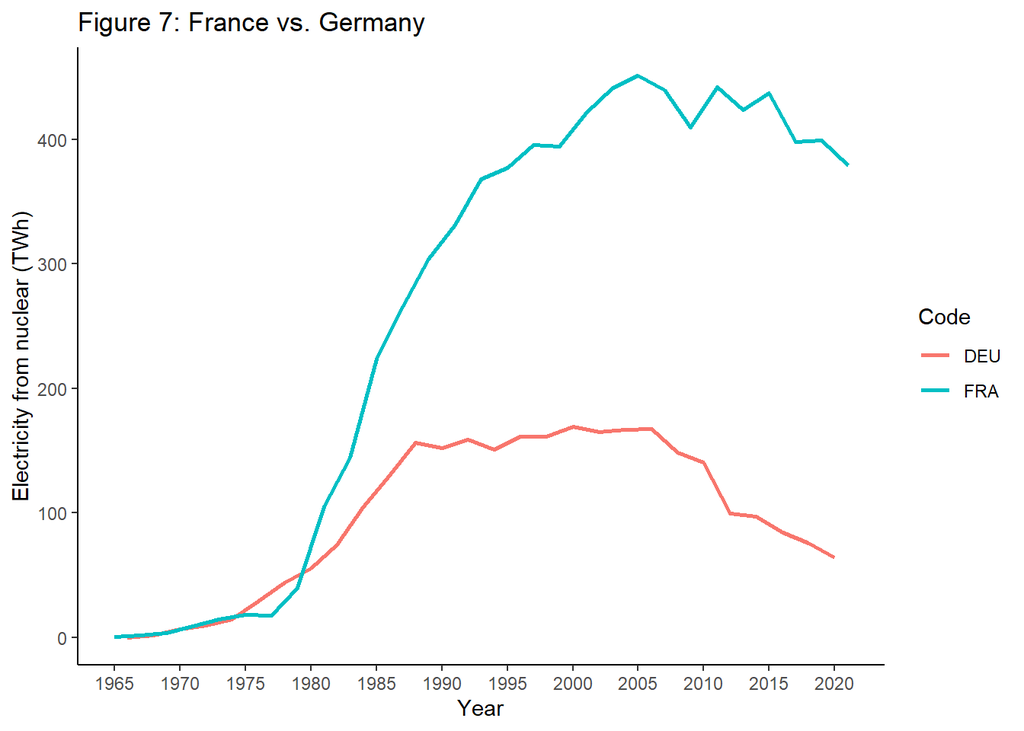

### 2.4 Energy Breakdown/Carbon Emission of France and Germany

This next section continues the analysis of France and Germany but looks at how each country’s energy sources affect their carbon foot print (i.e. amount of carbon emissions)

#### 2.4.1 France and Germany’s Energy Breakdown

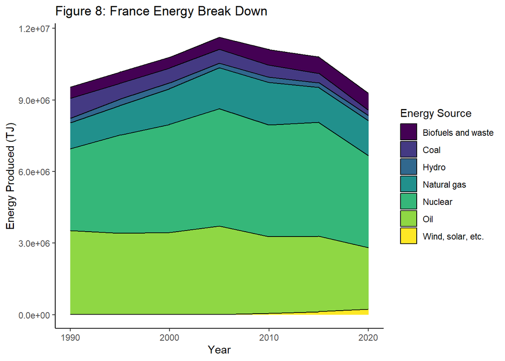

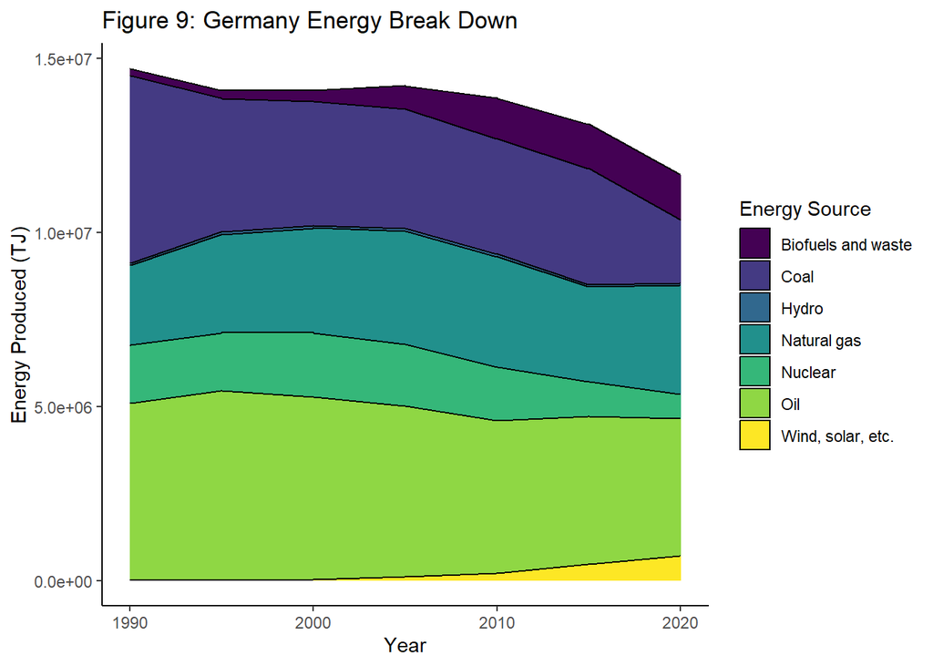

#### 2.4.2 France and Germany’s Carbon Emission Breakdown

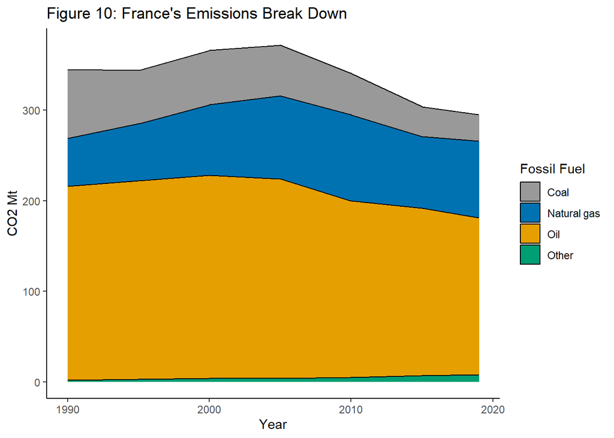

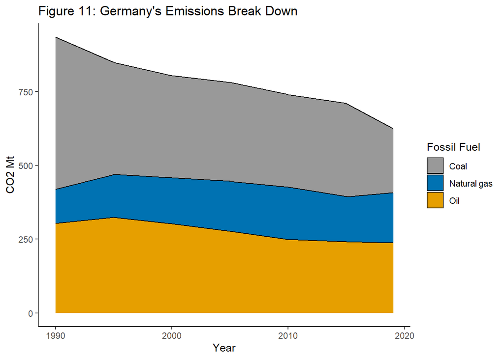

### 2.5 Public Opinion of Nuclear Energy in France and Germany

With the energy to carbon emission breakdown complete, this next section will investigate whether public opinion may influence the energy preferences of France and Germany.

#### 2.5.1 Public Opinion Comparision 2003 vs. 2021

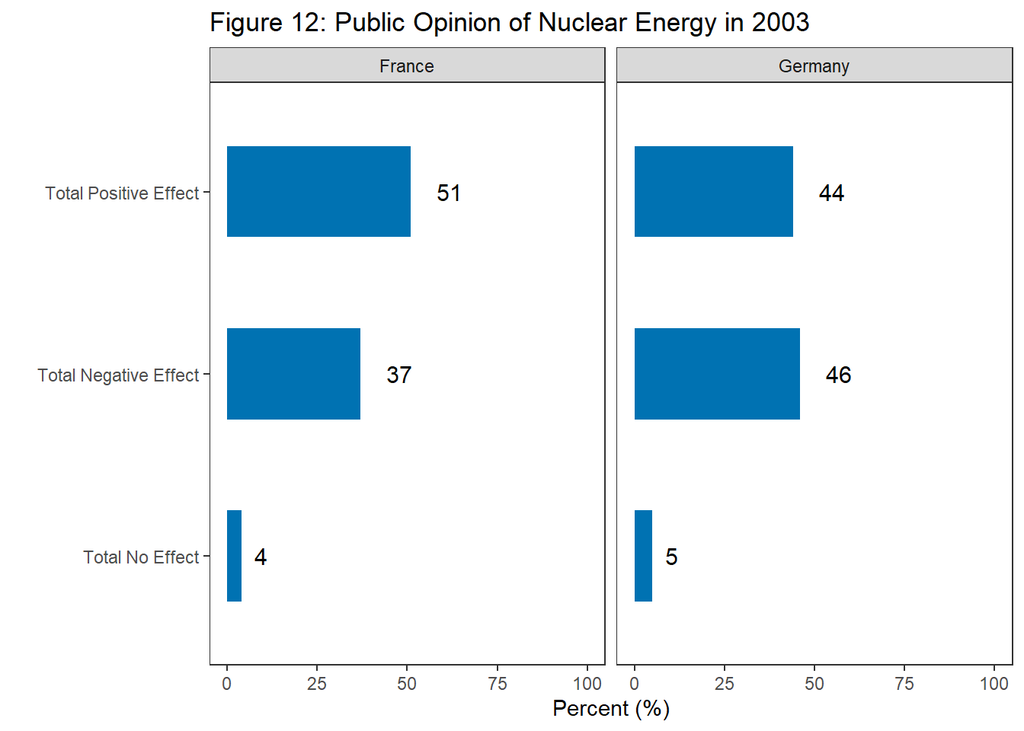

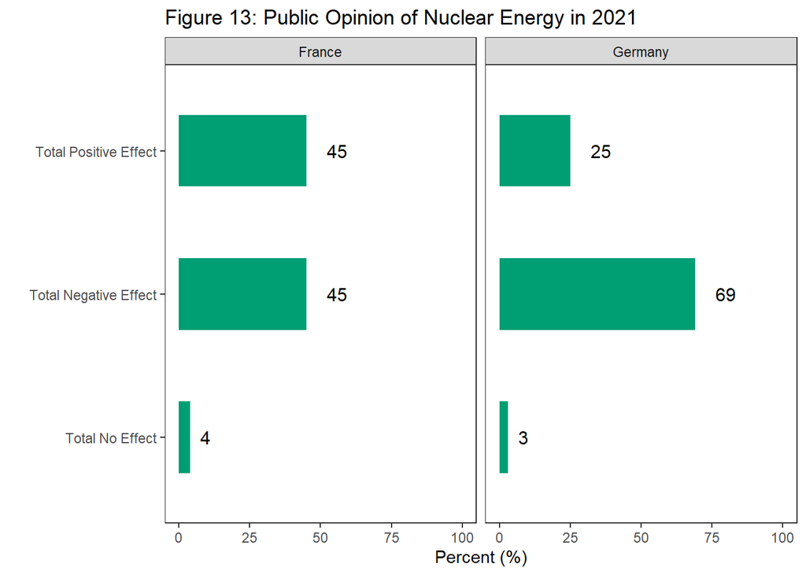

Figures 12 and 13 reveal the France and Germany’s public opinions on nuclear energy. Specifically, the public was asked “do you think [nuclear energy for energy production] will have a positive, a negative or no effect on our way of life in the next 20 years?” This question was asked in a scientific survey by Eurobarometer to understand European citizens’ knowledge and attitudes towards science and technology. The resulting data in Figures 12 and 13 visualize how opinions have changed since 2003. Looking at 2003, 51% of France’s public perceived nuclear energy as a positive while only 37% saw it as a negative. Reflecting on the nuclear energy production shown in Figure 7 it makes sense that public opinion would be high with regards to nuclear energy. Furthermore in 2003, Germany’s public had 44% believing nuclear energy was a positive and 46% stating it was a negative. Like France, Germany’s public also follows the nuclear energy production seen in Figure 7.

Looking at Figure 13, which asks the same question but in 2021, public opinion in both countries changed drastically. Starting with France, positive and negative views are both roughly 45%. Therefore, positive views of nuclear energy in France dropped by 6% over 18 years. This result explains why in France nuclear energy production has not increased and why there are no plans for future nuclear reactors. Alternatively, from Figure 13, it reveals that more of the German public see nuclear energy as a negative. Negative perception of nuclear energy grew by 23% across the last 18 years in Germany. Reflecting on Germany’s drop in nuclear energy production and significant amount of shutdown reactors, sharing such a negative opinion of nuclear energy among it citizens does not come as a surprise.

## 4. References

1. “Energy Statistics Data Browser – Data Tools.” n.d. IEA. Accessed December 13, 2022. https://www.iea.org/data-and-statistics/data-tools/energy-statistics-data-browser.
2. European Commission. Joint Research Centre. 2022. CO2 Emissions of All World Countries:JRC/IEA/PBL 2022 Report. LU: Publications Office. https://data.europa.eu/doi/10.2760/730164.
3. “Nuclear Power Reactors in the World.” 2022. Text. IAEA. June 23, 2022. https://www.iaea.org/publications/15211/nuclear-power-reactors-in-the-world.
4. “Special Eurobarometer 516: European Citizens’ Knowledge and Attitudes towards Science and Technology - Data Europa EU.” n.d. Accessed December 13, 2022. https://data.europa.eu/data/datasets/s2237_95_2_516_eng?locale=en.